# Travelpac Analysis Project

2025-04-07

# Overseas Travel and Tourism: An Analysis

## The data

The Travelpac dataset, found on the Office for National Statistics website here (https://www.ons.gov.uk/peoplepopulationandcommunity/leisureandtourism/datasets/travelpac), contains estimates of international visits with details on traveller age and sex, trip purpose, length, and spending from the International Passenger Survey (IPS).

## Our Aims

We wish to generate insights on tourism trends and habits, which can be used in a multitude of applications. We will pretend to work for a fictional travel agent. We wish to maximise our profit on our new luxury travel package, and need to work out who to advertise this to.

# Set up

### Packages

We load our packages. The tidyverse library contains the dplyr package, which will be useful for data handling, and the ggplot2 package, which we will use for visualisations.

```r
suppressPackageStartupMessages(library(tidyverse))
suppressPackageStartupMessages(library(readxl))
suppressPackageStartupMessages(library(paletteer))
```

### Data

Let us load in our raw data.

```r
travel_raw=read_excel('travelpac_raw/Travelpac 2023.xlsx',
                      sheet=2)
```

# Exploratory Analysis

### Summary

Let’s take a quick look at the data structure.

```r
summary(travel_raw)
```

```
##       Year        quarter              ukos               mode
##  Min.   :2023   Length:33706       Length:33706       Length:33706
##  1st Qu.:2023   Class :character   Class :character   Class :character
##  Median :2023   Mode  :character   Mode  :character   Mode  :character
##  Mean   :2023
##  3rd Qu.:2023
##  Max.   :2023
##
##    country            purpose            package              Age
##  Length:33706       Length:33706       Length:33706       Length:33706
##  Class :character   Class :character   Class :character   Class :character
##  Mode  :character   Mode  :character   Mode  :character   Mode  :character
##
##
##
##
##      Sex              duration             visits              nights
##  Length:33706       Length:33706       Min.   :    88.79   Min.   :      0
##  Class :character   Class :character   1st Qu.:  1015.46   1st Qu.:   4861
##  Mode  :character   Mode  :character   Median :  1802.49   Median :  13049
##                                        Mean   :  3808.86   Mean   :  36468
##                                        3rd Qu.:  3617.90   3rd Qu.:  33970
##                                        Max.   :289133.58   Max.   :2005960
##                                        NA's   :1107        NA's   :1107
##      expend              sample
##  Min.   :        0   Min.   :  1.00
##  1st Qu.:   381220   1st Qu.:  1.00
##  Median :  1082125   Median :  1.00
##  Mean   :  3071089   Mean   :  2.65
##  3rd Qu.:  2891479   3rd Qu.:  2.00
##  Max.   :319338534   Max.   :161.00
##  NA's   :1           NA's   :19
```

We have some categorical variables, which we can use to stratify the data, such as sex, age group and travel purpose, and we have some numeric results, from which we can generate insights.

### Cleaning

We notice from looking at the dataset, that we have some NAs in the Sex variable. It is not clear how best to impute these, so we will just exclude these rows from the analysis.

```r
travel_cleaned <- travel_raw %>% drop_na(Sex)
```

We also have ‘D/K’ terms appearing in the age group column. Let’s remove these.

```r
travel_cleaned2 <- travel_cleaned[travel_cleaned$Age != 'D/K',]
```

We will standardise the variable names for ease of future use. This step is not required, but I prefer to have a consistent styling.

```r
travel_cleaned3 <- travel_cleaned2 %>% rename(year=Year,
                                              age=Age,
                                              sex=Sex)
```

We have a few final things to tidy up before we are ready to do some analysis. First, every single year in this data extract is 2023, so this is an unnecessary column to have. Secondly, there is a value of ‘0’ in the country column - let’s remove this row. Sample is a row containing information on the number of sources used when creating the dataset. Whilst useful, this is not particularly relevant to our use case, so we will drop this. Lastly, let us create an analysis flag for UK residents.

```r
travel_final <- travel_cleaned3 %>%
                  select(-year,-sample) %>%
                  filter(country != '0') %>%
                  mutate(ukfl=ifelse(ukos=='UK residents',1,0))
```

## Analysis

Now that we have cleaned the data, we can start looking at some generating some valuable insights.

### 1. Countries Most Frequently Visited by UK Residents

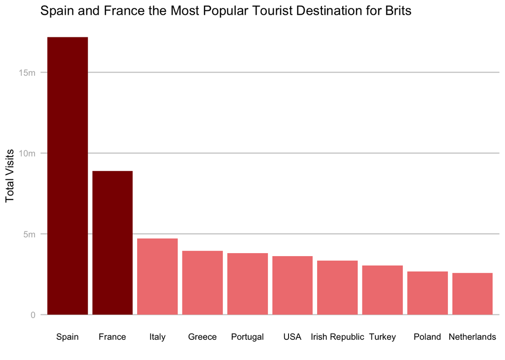

```r
t10cntry <- travel_final %>%
              filter(is.na(visits)==0 & ukfl==1) %>%
              group_by(country) %>%
              summarise(tot_vis = sum(visits)) %>%
              arrange(desc(tot_vis)) %>%
              head(10)

ggplot(t10cntry, aes(x = reorder(country, -tot_vis), y = tot_vis,
                     fill = ifelse(country %in% c("Spain", "France"), "darkred", "lightcoral"))) +
  geom_col() +
  labs(title = "Spain and France the Most Popular Tourist Destination for Brits", x='', y = "Total Visits") +
  theme_minimal() +
  scale_fill_identity() +
  theme(
    axis.text.y = element_text(color = "grey70"),  # Pale y-axis tick labels
    axis.text.x = element_text(color = "black"),   # Dark x-axis tick labels
    axis.ticks.x = element_blank(),               # Remove x-axis tick marks
    panel.grid.major.x = element_blank(),         # Remove vertical grid lines
    panel.grid.minor.x = element_blank(),
    panel.grid.major.y = element_line(color = "grey80"),  # Keep only horizontal grid lines
    panel.grid.minor.y = element_blank()          # Remove minor y grid lines
  ) +
  scale_y_continuous(
    breaks = c(0, 5000000, 10000000, 15000000),   # Custom tick positions
    labels = c('0','5m','10m','15m')   # Custom labels
  )
```

### 2. Expenditure by Sex

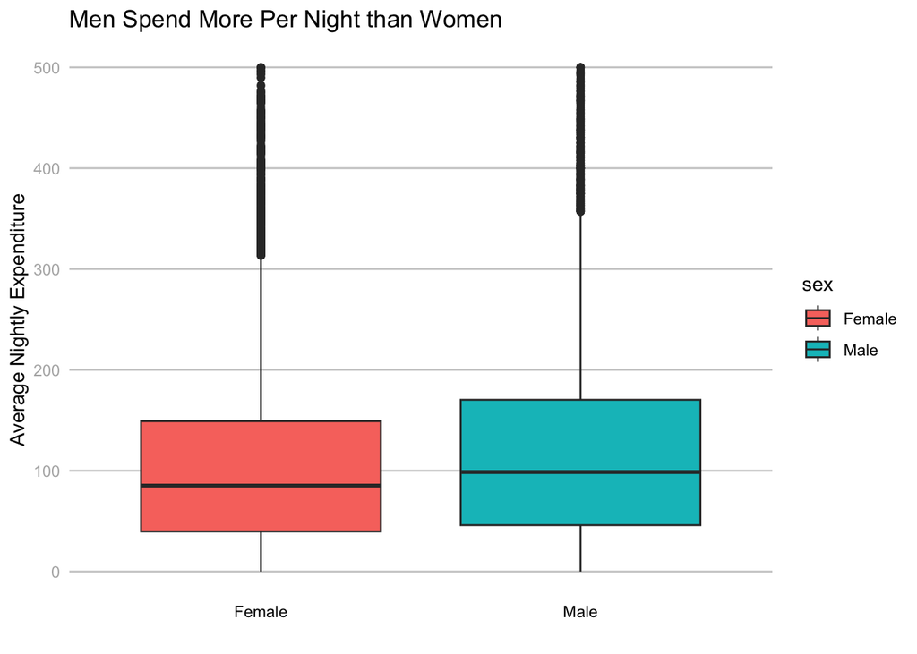

```r
spend_sex <- travel_final %>%
             filter(is.na(expend)==0 & is.na(nights)==0 & nights !=0) %>%
             group_by(sex) %>%
             summarise(mn_expend_night=mean(expend/nights))

travel_final_spend <- travel_final %>%
             filter(is.na(expend)==0 & is.na(nights)==0 & nights !=0) %>%
             mutate(expend_night=expend/nights) %>%
             filter((sex=='Male' | sex=='Female') & expend_night < 500)

ggplot(travel_final_spend, aes(x=sex,y=expend_night,fill=sex)) +
  geom_boxplot() +
  labs(title = "Men Spend More Per Night than Women", x='', y = "Average Nightly Expenditure") +
  theme_minimal() +
  theme(
    axis.text.y = element_text(color = "grey70"),  # Pale y-axis tick labels
    axis.text.x = element_text(color = "black"),   # Dark x-axis tick labels
    axis.ticks.x = element_blank(),               # Remove x-axis tick marks
    panel.grid.major.x = element_blank(),         # Remove vertical grid lines
    panel.grid.minor.x = element_blank(),
    panel.grid.major.y = element_line(color = "grey80"),  # Keep only horizontal grid lines
    panel.grid.minor.y = element_blank()          # Remove minor y grid lines
  )
```

### Quarterly Visits

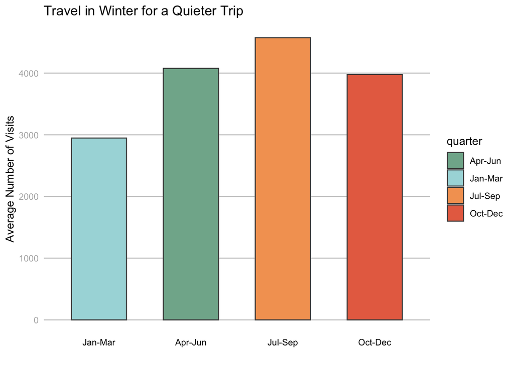

```r
travel_quart <- travel_final %>%
                  filter(is.na(visits)==0) %>%
                  group_by(quarter) %>%
                  summarise(mn_visnum=mean(visits)) %>%
                  arrange(desc(mn_visnum)) %>%
                  mutate(quart_ord=case_when(
                    quarter=='Jan-Mar' ~ 1,
                    quarter=='Apr-Jun' ~ 2,
                    quarter=='Jul-Sep' ~ 3,
                    quarter=='Oct-Dec' ~ 4))

ggplot(travel_quart, aes(x=reorder(quarter,quart_ord), y=mn_visnum, fill=quarter)) +
  geom_bar(stat='identity', width=0.6, color='grey30') +
  labs(title = "Travel in Winter for a Quieter Trip", x='', y = "Average Number of Visits") +
  theme_minimal() +
  theme(
    axis.text.y = element_text(color = "grey70"),  # Pale y-axis tick labels
    axis.text.x = element_text(color = "black"),   # Dark x-axis tick labels
    axis.ticks.x = element_blank(),               # Remove x-axis tick marks
    panel.grid.major.x = element_blank(),         # Remove vertical grid lines
    panel.grid.minor.x = element_blank(),
    panel.grid.major.y = element_line(color = "grey80"),  # Keep only horizontal grid lines
    panel.grid.minor.y = element_blank()          # Remove minor y grid lines
  ) +
  scale_fill_manual(values = c(
    "Jan-Mar" = "#A8DADC",   # soft icy blue (winter)
   "Apr-Jun" = "#81B29A",   # fresh sage green (spring)
   "Jul-Sep" = "#F4A261",   # warm orange (summer)
   "Oct-Dec" = "#E76F51"    # rustic red-orange (autumn))
  ))
```

## Statistical Analysis

We would like to determine which factors affect nightly expenditure, so that we can decide where to focus our marketing efforts. We will do this by fitting a linear model.

```r
travel_final_spend2 <- travel_final %>%
             filter(is.na(expend)==0 & is.na(nights)==0 & nights !=0) %>%
             mutate(expend_night=expend/nights)

lmod1 <- lm(data=travel_final_spend2, formula = expend_night ~ sex + quarter + ukfl + age)

summary(lmod1)
```

```
##
## Call:
## lm(formula = expend_night ~ sex + quarter + ukfl + age, data = travel_final_spend2)
##
## Residuals:
##     Min      1Q  Median      3Q     Max
##  -208.0   -88.0   -38.0    32.3 12356.1
##
## Coefficients:
##                Estimate Std. Error t value Pr(>|t|)
## (Intercept)     117.080    229.337   0.511 0.609694
## sexFemale       -14.031    229.191  -0.061 0.951184
## sexMale          11.260    229.188   0.049 0.960818
## quarterJan-Mar   -3.604      3.758  -0.959 0.337461
## quarterJul-Sep  -13.349      3.667  -3.640 0.000273 ***
## quarterOct-Dec   10.317      3.834   2.691 0.007130 **
## ukfl            -44.716      2.667 -16.764  < 2e-16 ***
## age16-24         12.206      8.296   1.471 0.141190
## age25-34         44.964      7.907   5.686 1.31e-08 ***
## age35-44         58.299      7.891   7.388 1.53e-13 ***
## age45-54         69.323      7.947   8.724  < 2e-16 ***
## age55-64         60.235      8.062   7.471 8.16e-14 ***
## age65 & over     25.269      8.312   3.040 0.002367 **
## ---
## Signif. codes:  0 '***' 0.001 '**' 0.01 '*' 0.05 '.' 0.1 ' ' 1
##
## Residual standard error: 229.1 on 29644 degrees of freedom
## Multiple R-squared:  0.02209,    Adjusted R-squared:  0.02169
## F-statistic:  55.8 on 12 and 29644 DF,  p-value: < 2.2e-16
```

The overall F statistic has a p-value which suggests at least one of our varuables has an effect on nightly expenditure. Notably, the R-squared is quite low, suggesting the rudimentary model we have formed is not a great fit. Let us see if we can improve this.